# Predicting Weight Lifting Exercise Quality

Aman

2026-10-25

## Summary

The goal is to predict the `classe` variable (A to E), which describes how a participant performed a barbell lift, using accelerometer data from the belt, forearm, arm and dumbbell. A is the correct form, and B to E are four common mistakes. I trained a random forest with 5-fold cross-validation, held out 30% of the training data to estimate out-of-sample error, and used the final model to predict the 20 test cases.

Data source: Velloso, E., Bulling, A., Gellersen, H., Ugulino, W., Fuks, H. *Qualitative Activity Recognition of Weight Lifting Exercises.* Proceedings of the 4th Augmented Human International Conference, 2013. http://groupware.les.inf.puc-rio.br/har

## Loading and cleaning the data

```r
library(caret)
library(randomForest)

train_url <- "https://d396qusza40orc.cloudfront.net/predmachlearn/pml-training.csv"
test_url  <- "https://d396qusza40orc.cloudfront.net/predmachlearn/pml-testing.csv"

training <- read.csv(train_url, na.strings = c("NA", "", "#DIV/0!"))
testing  <- read.csv(test_url,  na.strings = c("NA", "", "#DIV/0!"))
dim(training)
```

```
## [1] 19622   160
```

Cleaning steps and why:

1. **Dropped the first 7 columns** (row index, user name, timestamps, window info). They are identifiers, not sensor measurements, and would let the model “cheat” on this dataset without generalizing.
2. **Dropped columns that are mostly NA** (more than 90% missing). These are summary statistics (kurtosis, skewness, etc.) only filled in on window-end rows, and are empty in the test set anyway.
3. Applied the same column selection to the test set.

```r
training <- training[, -(1:7)]
training <- training[, colMeans(is.na(training)) < 0.9]
training$classe <- factor(training$classe)

predictor_cols <- setdiff(names(training), "classe")
testing <- testing[, predictor_cols]

length(predictor_cols)
```

```
## [1] 52
```

This leaves 52 predictors and no missing values.

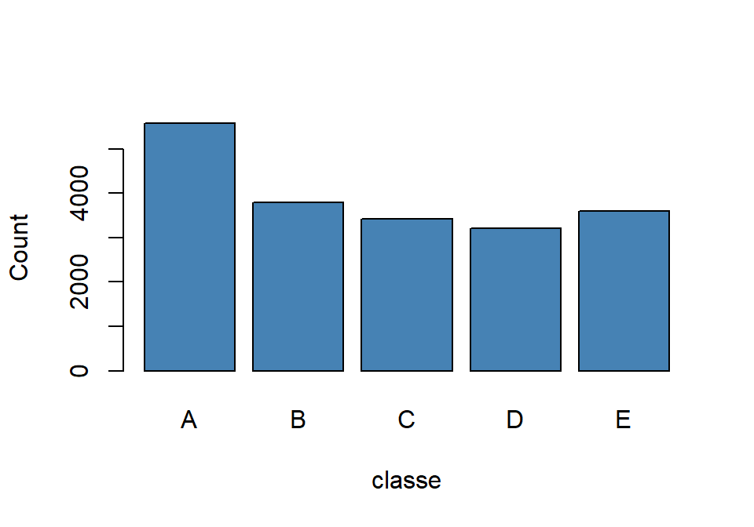

Figure 1: Distribution of the classe outcome in the training data.

```r
barplot(table(training$classe), col = "steelblue",
        xlab = "classe", ylab = "Count")
```

The classes are reasonably balanced (A is somewhat more frequent), so plain accuracy is a fair metric.

## Model building

I split the training data 70/30 into a training set and a validation set. The validation set is never used for fitting or tuning, so it gives an honest estimate of out-of-sample error.

I chose a **random forest** because it handles many correlated numeric predictors, needs little preprocessing (no scaling required), captures non-linear interactions, and is known to work very well on this kind of sensor data.

**Cross-validation:** 5-fold CV inside the 70% training split, used to pick the `mtry` tuning parameter and to get a CV estimate of accuracy.

```r
set.seed(123)
in_train <- createDataPartition(training$classe, p = 0.7, list = FALSE)
trn <- training[in_train, ]
val <- training[-in_train, ]

ctrl <- trainControl(method = "cv", number = 5)

fit <- train(classe ~ ., data = trn, method = "rf",
             trControl = ctrl, ntree = 100)
fit
```

```
## Random Forest
##
## 13737 samples
##    52 predictor
##     5 classes: 'A', 'B', 'C', 'D', 'E'
##
## No pre-processing
## Resampling: Cross-Validated (5 fold)
## Summary of sample sizes: 10990, 10990, 10989, 10988, 10991
## Resampling results across tuning parameters:
##
##   mtry  Accuracy   Kappa
##    2    0.9893723  0.9865545
##   27    0.9907551  0.9883052
##   52    0.9856596  0.9818588
##
## Accuracy was used to select the optimal model using the largest value.
## The final value used for the model was mtry = 27.
```

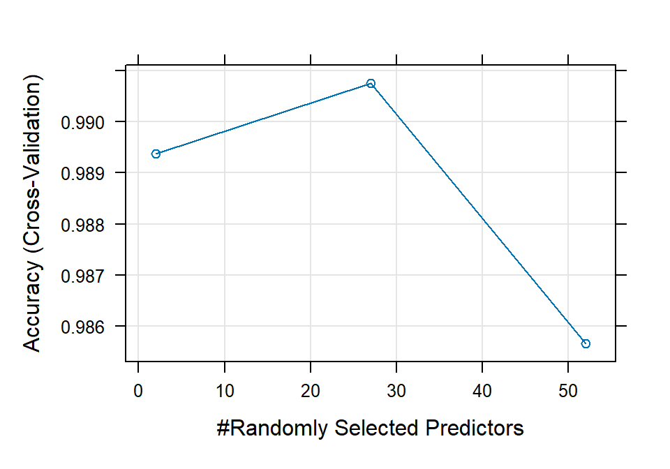

Figure 2: Cross-validated accuracy by number of predictors tried at each split (mtry).

```r
plot(fit)
```

The best CV accuracy was **0.9908** (mtry = 27).

## Out-of-sample error

```r
pred_val <- predict(fit, val)
cm <- confusionMatrix(pred_val, val$classe)
cm$table
```

```
##           Reference
## Prediction    A    B    C    D    E
##          A 1673    5    0    0    0
##          B    1 1127    5    0    0
##          C    0    7 1020   10    5
##          D    0    0    1  954    6
##          E    0    0    0    0 1071
```

```r
cm$overall["Accuracy"]
```

```
##  Accuracy
## 0.9932031
```

Accuracy on the held-out validation set is **0.9932**, so the **expected out-of-sample error is about 0.0068** (0.68%). The cross-validation estimate (0.0092 error) agrees closely with this, which suggests the model is not overfitting. The error on the final 20 test cases should be similar, with the caveat that 20 samples is a tiny sample, so the observed result can vary a lot by chance.

## Predictions for the 20 test cases

```r
test_pred <- predict(fit, testing)
data.frame(problem_id = 1:20, prediction = test_pred)
```

```
##    problem_id prediction
## 1           1          B
## 2           2          A
## 3           3          B
## 4           4          A
## 5           5          A
## 6           6          E
## 7           7          D
## 8           8          B
## 9           9          A
## 10         10          A
## 11         11          B
## 12         12          C
## 13         13          B
## 14         14          A
## 15         15          E
## 16         16          E
## 17         17          A
## 18         18          B
## 19         19          B
## 20         20          B
```

```r
# Optional: write one file per prediction (not run during knit)
for (i in seq_along(test_pred)) {
  write.table(as.character(test_pred[i]),
              file = paste0("problem_id_", i, ".txt"),
              quote = FALSE, row.names = FALSE, col.names = FALSE)
}
```

## Conclusion

A random forest with 5-fold cross-validation, trained on 52 sensor predictors after removing identifier and mostly-empty columns, achieved roughly 99% accuracy on held-out data. The expected out-of-sample error is under 1%, and this model was used to generate the predictions above for the quiz.